## Load libraries

Firstly, let’s load the libraries that we will use.

They will need to be installed first if you don’t already have them.

```r
#install.packages('writexl')
library(writexl)
#install.packages("RNetCDF")
library(RNetCDF)
```

## Introducing the data

In this example, we will be loading a depth profile of some Chlorophyll A data. However, this example should be relevant for depth profiles of any data.

Nansen Legacy data can be found via the SIOS data access portal. All Nansen Legacy datasets should be returned when filtering using the ‘AeN’ collection. Please contact data.nleg@unis.no if you have any problems finding or accessing data.

I have downloaded the following dataset into my directory.

## Loading the data

```r
data <- open.nc("AeN_SeaWaterChlorophyllA_20191210_P2.nc")
print.nc(data)
```

```
## netcdf classic4 {
## dimensions:
##  DEPTH = 168 ;
##  NCHAR = 36 ;
## variables:
##  NC_INT DEPTH(DEPTH) ;
##      NC_INT DEPTH:_FillValue = -1 ;
##      NC_CHAR DEPTH:units = "metres" ;
##      NC_CHAR DEPTH:long_name = "Sample depth below sea level, positive is increasing depth" ;
##      NC_CHAR DEPTH:standard_name = "depth" ;
##      NC_CHAR DEPTH:coverage_content_type = "physicalMeasurement" ;
##      NC_CHAR DEPTH:positive = "down" ;
##  NC_DOUBLE CHLOROPHYLL_A(DEPTH) ;
##      NC_DOUBLE CHLOROPHYLL_A:_FillValue = -1 ;
##      NC_CHAR CHLOROPHYLL_A:units = "kg m-3" ;
##      NC_CHAR CHLOROPHYLL_A:long_name = "Mass concentration of Chlorophyll A in sea water, after acid correction" ;
##      NC_CHAR CHLOROPHYLL_A:standard_name = "mass_concentration_of_chlorophyll_a_in_sea_water" ;
##      NC_CHAR CHLOROPHYLL_A:coverage_content_type = "physicalMeasurement" ;
##  NC_FLOAT FILTERED_VOLUME(DEPTH) ;
##      NC_FLOAT FILTERED_VOLUME:_FillValue = -1 ;
##      NC_CHAR FILTERED_VOLUME:units = "l" ;
##      NC_CHAR FILTERED_VOLUME:long_name = "Volume of sea water filtered for measurement" ;
##      NC_CHAR FILTERED_VOLUME:coverage_content_type = "physicalMeasurement" ;
##  NC_DOUBLE PHAEOPIGMENT(DEPTH) ;
##      NC_DOUBLE PHAEOPIGMENT:_FillValue = -1 ;
##      NC_CHAR PHAEOPIGMENT:units = "kg m-3" ;
##      NC_CHAR PHAEOPIGMENT:long_name = "Mass concentration of phaeopigment in sea water, after acid correction" ;
##      NC_CHAR PHAEOPIGMENT:coverage_content_type = "physicalMeasurement" ;
##  NC_INT NCHAR(NCHAR) ;
##      NC_INT NCHAR:_FillValue = -1 ;
##      NC_CHAR NCHAR:units = "" ;
##      NC_CHAR NCHAR:long_name = "Character number in string" ;
##  NC_CHAR EVENT_ID(NCHAR, DEPTH) ;
##      NC_CHAR EVENT_ID:_FillValue = "?" ;
##      NC_CHAR EVENT_ID:units = "" ;
##      NC_CHAR EVENT_ID:long_name = "Event ID is a universally unique ID (UUID) for each event. This can be linked to the metadata catalogue on the SIOS webpage https://sios-svalbard.org/reports/aen_multi" ;
##
## // global attributes:
##      NC_CHAR :id = "37ca1c97-7fe4-58ca-8dac-838c4318979c" ;
##      NC_CHAR :naming_authority = "The University Centre in Svalbard, Norway" ;
```

[output cut: 29 more lines]

```
##      NC_CHAR :publisher_url = "https://www.unis.no/staff/luke-marsden/" ;
##      NC_CHAR :project = "The Nansen Legacy (RCN # 276730)" ;
##      NC_CHAR :acknowledgements = "Funded by the Research Council of Norway" ;
##      NC_CHAR :stationName = "P2" ;
##      NC_DOUBLE :cruiseNumber = 2019711 ;
##      NC_CHAR :recordedBy = "Miriam, Yasemin, Anna" ;
##      NC_CHAR :samplingProtocol = "The sampling protocol can be found in section 8.22 of
##             https://sios-svalbard.org/sites/sios-svalbard.org/files/common/AeN/Nansen_Legacy_Sampling_Protocols_Version_1.pdf" ;
##      NC_CHAR :sampleType = "Chlorophyll a tot" ;
##      NC_CHAR :pi_name = "Anna Vader" ;
##      NC_CHAR :pi_institution = "UNIS" ;
##      NC_CHAR :pi_email = "annav@unis.no" ;
##      NC_CHAR :pi_address = "Forskningsparken, Longyearbyen" ;
##      NC_DOUBLE :bottomDepthInMetres = 190 ;
## }
```

At a glance, we can see it has 2 dimensions; they denote that there are 168 depth points and 36 characters (NCHAR).

There are 2 coordinate variables, with the same name as the dimensions.

There are 4 data variables. The CHLOROPHYLL_A, FILTERED_VOLUME and PHAEOPIGMENT variables all have depth as their dimension. This means that the first chlorophyll a value corresponds to the first depth value.

The EVENT_ID has two dimensions, DEPTH and NCHAR. This is therefore a 2 dimensional array. This tells us that there is a maximum of one EVENT_ID for each of the 168 depths, and it has 36 characters - though variables can have missing values, denoted using a fill value. More on this later.

Finally, we have a long list of global attributes.

## A closer look

We can access a variable attribute like this:

```r
att.get.nc(data, "CHLOROPHYLL_A", "units")
```

```
## [1] "kg m-3"
```

Or we can use the special “NC_GLOBAL” variable name to access a global attribute, like this:

```r
att.get.nc(data, "NC_GLOBAL", "creator_name")
```

```
## [1] "Anna Vader, Rita Amundsen"
```

Let’s write our Chlorophyll A data out as a variable we can easily use later:

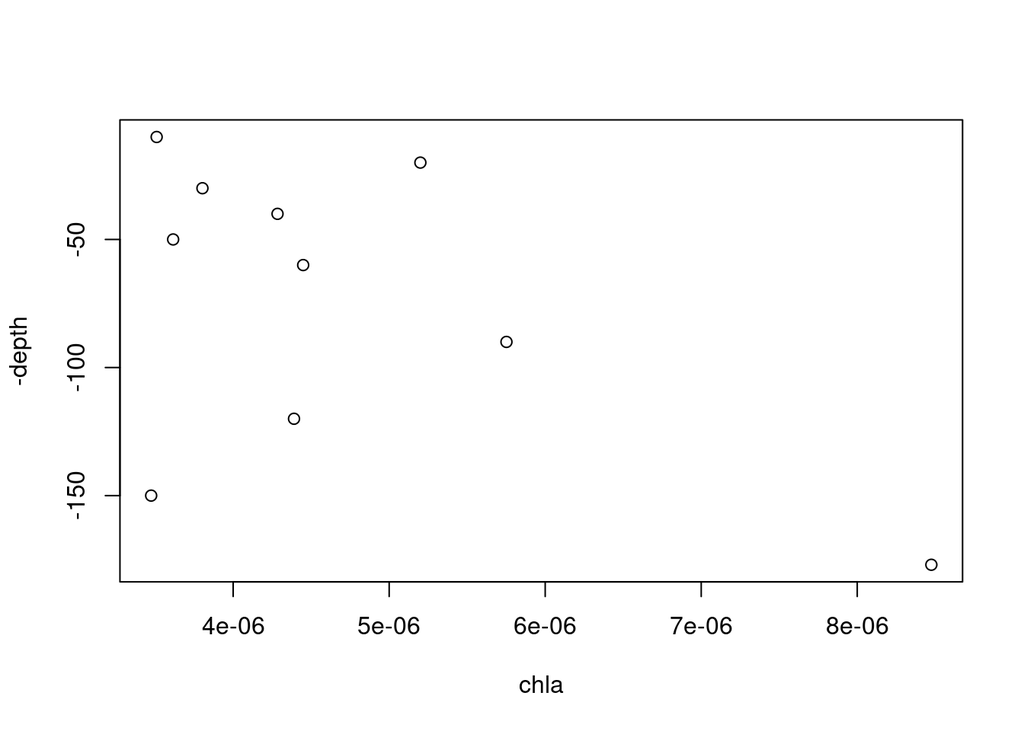

```r
chla <- var.get.nc(data, "CHLOROPHYLL_A")
depth <- var.get.nc(data, "DEPTH")
phaeopigment <- var.get.nc(data, "PHAEOPIGMENT")
filteredvol <- var.get.nc(data, "FILTERED_VOLUME")
plot(chla, -depth)
```

## Outputting to Excel

To output the data to Excel, we can first create a dataframe.

```r
df <- data.frame(Depth = depth, ChlorophyllA = chla, Phaeopigment = phaeopigment, FilteredVolume = filteredvol)
df
```

```
##     Depth ChlorophyllA Phaeopigment FilteredVolume
## 1      10 3.509737e-06 7.460890e-06              1
## 2      11           NA           NA             NA
## 3      12           NA           NA             NA
## 4      13           NA           NA             NA
## 5      14           NA           NA             NA
## 6      15           NA           NA             NA
## 7      16           NA           NA             NA
## 8      17           NA           NA             NA
## 9      18           NA           NA             NA
## 10     19           NA           NA             NA
## 11     20 5.200045e-06 7.643185e-06              1
## 12     21           NA           NA             NA
## 13     22           NA           NA             NA
## 14     23           NA           NA             NA
```

[output cut: 154 more lines]

Let’s remove the rows with NAs

```r
df <- na.omit(df)
df
```

```
##     Depth ChlorophyllA Phaeopigment FilteredVolume
## 1      10 3.509737e-06 7.460890e-06              1
## 11     20 5.200045e-06 7.643185e-06              1
## 21     30 3.803193e-06 7.414759e-06              1
## 31     40 4.284461e-06 7.110151e-06              1
## 41     50 3.615381e-06 6.754600e-06              1
## 51     60 4.448797e-06 7.228473e-06              1
## 81     90 5.751743e-06 8.027789e-06              1
## 111   120 4.390105e-06 7.022173e-06              1
## 141   150 3.474522e-06 8.467739e-06              1
## 168   177 8.475016e-06 8.979057e-06              1
```

And then to output

```r
write_xlsx(df, '/home/lukem/chlorophyll_a_data_20191210_P2.xlsx')
```